# How to Avoid your Error for Investments

Wenying Gu

9/3/2019

### Email: wenying.gu@vanderbilt.edu

## Monte Carlo Smiluation

Monte Carlo smiluation is always repeat random sampling to estimate numerical results. But the simulation may have some error when generate approximate answers.Therefore, it is necessary to know the error for each replicate number. For exmaple, when you flip a coin for 10 times, the head shows up 6 times. So 6 is the sum of out. Then the phat (mean of out) is 6/10=0.6 (mean of out/replicates). But the real probability for get a head is 0.5. Therefore, the absolute error is |phat-probability|=|0.6-0.5|=0.1. Relative error is relative error/probability= 0.1/0.5=0.2

Here is the formula for absolute error and relative error

absolute error = |p̂−p|

and

relative error = |p̂−p|/p.

## Matrix Method

```r
p <- c(0.01, 0.05, 0.10, 0.25, 0.50) #probability
R <- 2^(2:15) #R
abs_error<- matrix(NA,length(R),length(p)) #matrix is one way to do it, also try dataframes later.
for(i in 1: length(p)){
  for (j in 1:length(R)){
    abs_error[j,i]<-mean(abs(rbinom(200,R[j],p[i])/R[j] - p[i]))

  }
}
```

Absolute error

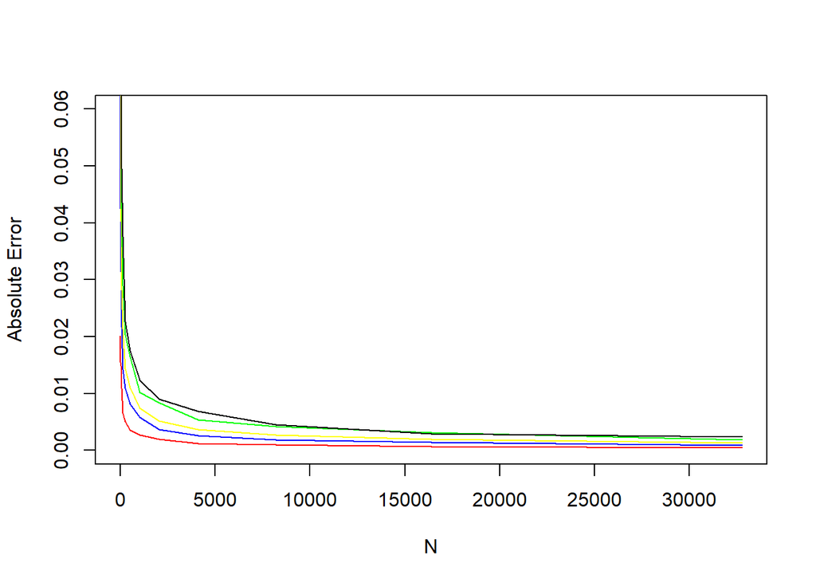

```r
plot(R,seq(0,.06,length.out= length(R)),type="n",xlab = "N", ylab = "Absolute Error")
lines(R, abs_error[,1], col="red")
lines(R, abs_error[,2], col="blue")
lines(R, abs_error[,3], col="yellow")
lines(R, abs_error[,4], col="green")
lines(R, abs_error[,5], col="black")
```

Relative error

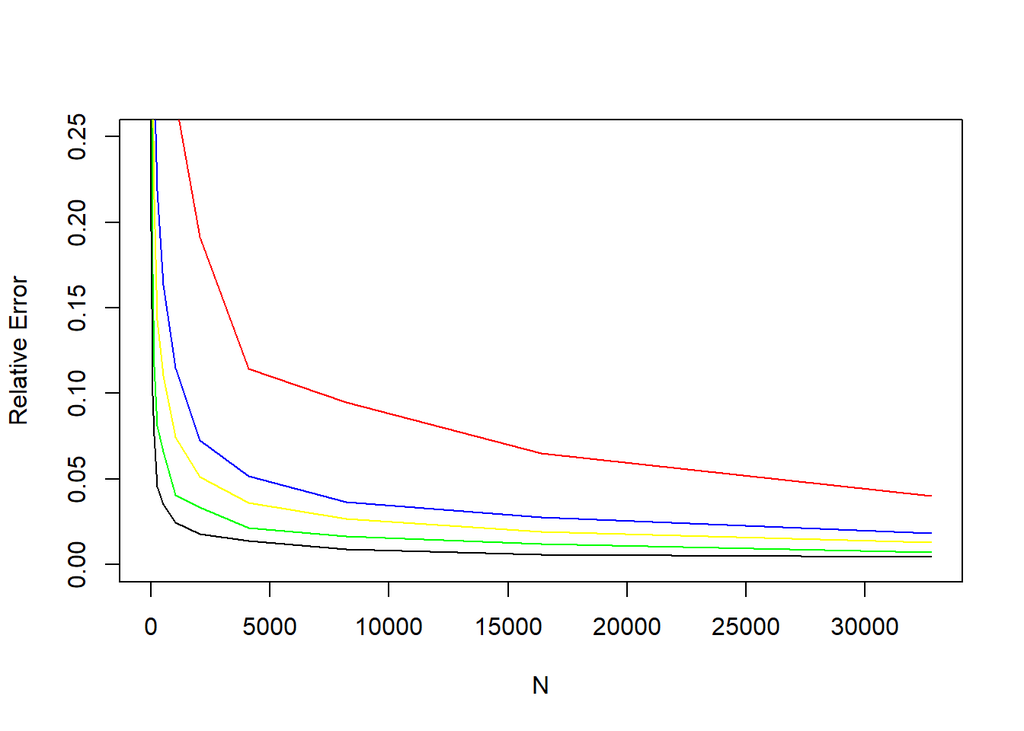

```r
rel_error <- matrix(NA, length(R), length(p))

for (i in 1: length(R)) {
  rel_error[i,] <- (abs_error[i,]/p)
}

plot(R,seq(0,.25,length.out= length(R)),type="n",xlab = "N", ylab = "Relative Error")
lines(R, rel_error[,1], col="red")
lines(R, rel_error[,2], col="blue")
lines(R, rel_error[,3], col="yellow")
lines(R, rel_error[,4], col="green")
lines(R, rel_error[,5], col="black")
```

## Dataframes Method

```r
library(tidyverse)
library(ggplot2)
```

Absolute error

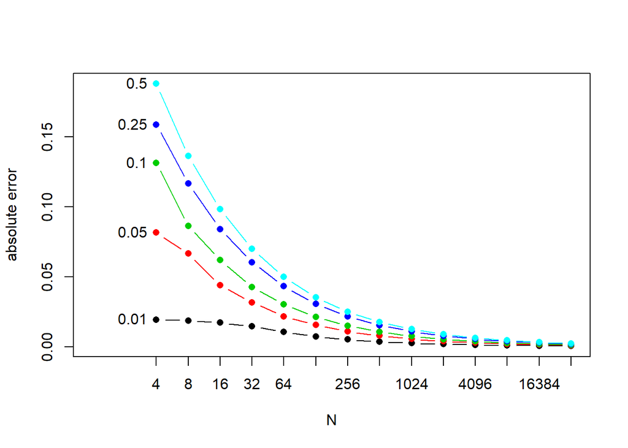

```r
ss1 <- expand.grid(
  N = 2^(2:15),
  p = c(0.5, 0.25, 0.1, 0.05, 0.01),
  mae = NA_real_,
  mre = NA_real_
  )

one_calc <- function (N,p){
  Y<-rbinom(100000, N, p)
  phat <- Y/N
  abs_error <- abs(phat - p)
  rel_error <- abs_error/p
  c(mean(abs_error), mean(rel_error))
}

for(i in 1: nrow(ss1)){
  ss1[i,c("mae", "mre")]<- one_calc(ss1[i, "N"], ss1[i,"p"])
}

ss1$xlog2 <- log2(ss1$N)
plot.new()
plot.window(xlim=range(0, 15), ylim=range(ss1$mae)) #xlim=range(ss1$xlog2)
l1<- ss1 %>% split(.$p)
for(j in seq_along(l1)){
  lines(l1[[j]]$xlog2, l1[[j]]$mae, type="b", pch=16, col=j)
  text(2, l1[[j]]$mae[1], l1[[j]]$p[1], pos=2)
}


axis(1, 2:15, 2^(2:15))
axis(2)
box()
title(xlab="N")
title(ylab="absolute error")
```

```r
#use T's package to plot
# ss1 %>%
#   plot_setup(mae~xlog2) %>%
#   split(.$p) %>%
#   lwith(lines(xlog2,))
```

Relative error

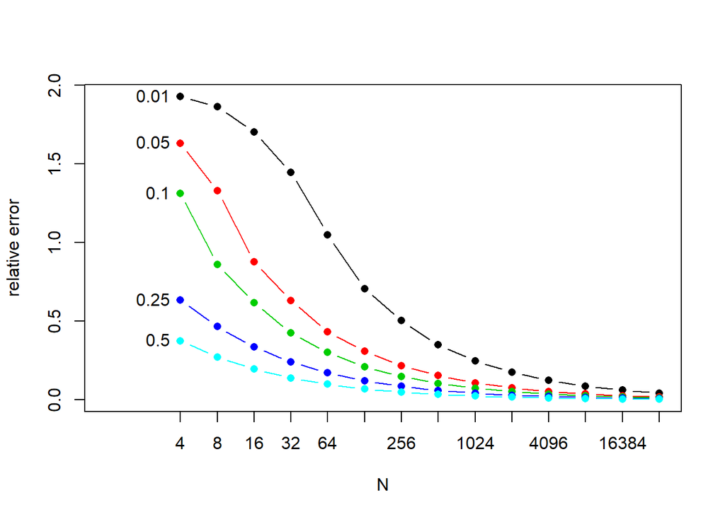

```r
ss1$xlog2 <- log2(ss1$N)
plot.new()
plot.window(xlim=range(0, 15), ylim=range(ss1$mre)) #xlim=range(ss1$xlog2)
l1<- ss1 %>% split(.$p)
for(j in seq_along(l1)){
  lines(l1[[j]]$xlog2, l1[[j]]$mre, type="b", pch=16, col=j)
  text(2, l1[[j]]$mre[1], l1[[j]]$p[1], pos=2)
}

axis(1, 2:15, 2^(2:15))
axis(2)
box()
title(xlab="N")
title(ylab="relative error")
```